# Fundamentos de Data Science: PEC1 - Text Mining

# 10 Validación del Modelo de clasificación

Una vez aplicado el modelo K-NN sobre el juego de documentos de prueba, podemos utilizar una **matriz de confusión** para valorar el nivel de acierto del modelo.

```r
# Modelo KNN
knn.pred <- knn(pila.nl[entrena.idx, ], pila.nl[test.idx, ], tema[entrena.idx])
# Matriz de confusión
# Las filas son predicciones y las columnas son observaciones reales
conf.mat <- table("Predicción" = knn.pred,"Real" = tema[test.idx])
conf.mat
```

```
##           Real
## Predicción acq earn
##       acq  470   15
##       earn  20  825
```

Para evaluar la capacidad predictiva del algoritmo utilizamos dos medidas, que hemos denominado ratio1 y rati2.

```r
ratio1 <- (conf.mat[1,1]/(conf.mat[1,1]+conf.mat[2,1]))*100
ratio1
```

```
## [1] 95.91837
```

```r
ratio2 <- (conf.mat[2,2]/(conf.mat[1,2]+conf.mat[2,2]))*100
ratio2
```

```
## [1] 98.21429
```

## 10.1 Matriz de confusión con el paquete “caret”

Obtenemos una matriz de confusión más completa. Además de la precisión, la sensibilidad y la especificidad, esta matriz de confusión proporciona estadísticos que nos ayudan a valorar la capacidad informativa del modelo.

Es importante tener en cuenta que la categoría sobre la que calcula la probabilidad es la menor, o en caso de alfanuméricas la primera en el alfabeto. En este caso es acq (respecto a earn), esto lo indica al final de la matriz de confusión.

|  | Reference |  |
| --- | --- | --- |
| Predicted | Event | No Event |
| Event | A | B |
| No Event | C | D |

Los resultados son:

Sensitivity = A/(A+C)

Specificity = D/(B+D)

Prevalence = (A+C)/(A+B+C+D)

PPV = (sensitivity * prevalence)/((sensitivity * prevalence) + ((1-specificity) * (1-prevalence)))

NPV = (specificity * (1-prevalence))/(((1-sensitivity) * prevalence) + ((specificity) * (1-prevalence)))

Detection Rate = A/(A+B+C+D)

Detection Prevalence = (A+B)/(A+B+C+D)

Balanced Accuracy = (sensitivity+specificity)/2

Precision = A/(A+B)

Además de lo anterior la matriz de confusión también informa del

- porcentaje de acierto: Accuracy = (A+D)/(A+B+C+D)
- cociente no informativo (NIR): No Information Rate = (A+C)/(A+B+C+D) = Prevalence
- p-valor para el contraste de la $H_0: Accuracy>NIR$: $P-Value [Acc > NIR]$, es una medida de capacidad informativa del modelo. **Cuanto menor es el p-valor mejor**
- Estadístico Kappa: k= (Accuracy-Random Acc)/(1-Random Acc), donde Random Acc=(p1*p2)+(1-p1)*(1-p2), con p1=Prevalence y p2=Detection Prevalence. **Cuanto más próxima a 1 se sitúe el valor de Kappa mayor poder informativo del modelo**.

```r
dat_test<-cbind(pila.nl[test.idx, ],tema[test.idx])
preds_knn<-predict(knn.caret, dat_test)
# Matriz de confusión
confusionMatrix(preds_knn,as.factor(dat_test$`tema[test.idx]`))
```

```
## Confusion Matrix and Statistics
##
##           Reference
## Prediction acq earn
##       acq  473   14
##       earn  17  826
##
##                Accuracy : 0.9767
##                  95% CI : (0.9671, 0.9841)
##     No Information Rate : 0.6316
##     P-Value [Acc > NIR] : <2e-16
##
##                   Kappa : 0.9499
##
##  Mcnemar's Test P-Value : 0.7194
##
##             Sensitivity : 0.9653
##             Specificity : 0.9833
##          Pos Pred Value : 0.9713
##          Neg Pred Value : 0.9798
##              Prevalence : 0.3684
##          Detection Rate : 0.3556
##    Detection Prevalence : 0.3662
##       Balanced Accuracy : 0.9743
##
##        'Positive' Class : acq
##
```

# 11 Ejercicios

## 11.1 Ejercicio 1:

En el apartado “Generación de la Matriz de Términos”, un valor a controlar es la “Sparsity” que se fija en 0.80. Describa como se calcula el valor de la Sparsity que finalmente se consigue en ambas matrices de términos. ¿Qué implica que la “Sparsity” en la matriz de términos asociada a la temática earn sea menor?.

## 11.2 Respuesta 1:

> El valor “Sparsity” o dispersión de los términos nos indicará, si tiene un nivel alto, que habrán muchos términos que no aparecen en el resto de documentos (nos dará muchas celdas igual a 0 respecto al total). Nos indicará cuantos términos están en un documento pero en otros no.

> En el caso de un 0.80, nos indicará que hay un 80% de términos de términos que no aparecen en el resto de documentos.

> Para conseguir un valor de “Sparsity” del 80% se ha usado la función removeSparseTerms().

> En el caso de la temática “acq”, si realizamos un inspect de mat_acq antes de utilizar la función removeSparseTerms(), obtendríamos 1596 documentos y 7907 términos. Tendríamos un total de 12544124 ceros sobre un total de 12619572 celdas. Esto nos da una Sparsity del 99%, lo que significa que un 99% de celdas serían 0.

> En el caso de la temática “earn”, si realizamos un inspect de mat_acq antes de utilizar la función removeSparseTerms(), obtendríamos 2840 documentos y 7782 términos. Tendríamos un total de 22017017 ceros sobre un total 22100880. Esto nos daría una Sparsity del 100% (en realidad sería de un 99.6%, bastante cercano al 100%).

> Con la función removeSparseTerms se busca reducir esta dispersión.

> En el caso de la temática “acq” para conseguir un 80% de dispersión máxima aceptada, tendríamos que multiplicar el total de documentos por (1-80%). Es decir: 1596*(1-0.8)= 319.2 Se aceptaría, por tanto, que cada término apareciera en al menos 320 documentos. En el caso de “acq”, pasamos de 7907 términos a 20 términos en 1596 documentos (total de 31920). Ahora tendremos 20173 de celdas a 0, lo que nos dará una sparsity del 63% como nos indica el inspect

> En el caso de la temática “earn”, para conseguir un 80% de dispersión máxima aceptada, tendríamos que multiplicar el total de documentos por (1-80%). Es decir: 2840*(1-0.8)= 568 Se aceptarían que cada término apareciera en al menos 568 documentos. Pasaríamos entonces de 7782 términos a 22 términos en 2840 dcumentos (total de 62480 celdas). Tendríamos ahora 38001 celdas a 0, lo que daría una “sparsity” del 61% aprox como indicará la funcion inspect.

> Conseguir una menor “Sparsity” en “earn” ( o en cualquier otra temática), supone reducir la cantidad de términos de los que vamos a disponer, al condicionar a que cada término aparezca en al menos una cantidad de documentos determinada. Esto puede suponer una pérdida de información, lo que deberemos tener en cuenta para ajustar esta “Sparsity”. En el caso de “earn” en concreto pasaríamos de 7782 términos a 22, por lo que tendríamos que revisar si esta reducción supone una pérdida muy drástica de información.

## 11.3 Ejercicio 2:

En el apartado “Visualizaciones sobre la matriz de palabras TDM” se muestron algunos ejemplos de visualización de distintas secciones de la matriz de términos. Visualizad los 10 primeros términos y los 15 primeros documentos en la temática “acq” y todos los términos de los 5 primeros documentos de la temática “earn”. Posteriormente visualizar aquellas palabras relacionadas con esta misma temática y con frecuencia menor a 500 y mayor a 5.

## 11.4 Respuesta 2:

```r
#Visualizad los 10 primeros términos y los 15 primeros documentos en la temática "acq":
inspect(mat[[1]]$mat[1:10,1:15])
```

```
## <<TermDocumentMatrix (terms: 10, documents: 15)>>
## Non-/sparse entries: 80/70
## Sparsity           : 47%
## Maximal term length: 7
## Weighting          : term frequency (tf)
## Sample             :
##          Docs
## Terms     1 10 11 14 15 2 3 4 5 6
##   acquir  1  1  0  0  0 1 1 0 0 0
##   buy     1  1  1  2  1 0 1 0 0 0
##   common  3  0  0  0  1 0 0 2 0 2
##   compani 4  1  3  2  0 9 1 0 5 1
##   dlrs    4  1  0  1  3 4 0 1 2 1
##   inc     2  2  0  1  2 3 3 0 1 0
##   mln     1  1  0  1  2 3 0 1 3 1
##   pct     2  1  5  1  1 0 0 2 2 3
##   reuter  1  1  1  1  1 1 1 1 1 1
##   sale    2  0  0  0  0 0 0 0 0 0
```

```r
#Todos los términos de los 5 primeros documentos de la temática "earn":
inspect(mat[[2]]$mat[,1:5])
```

```
## <<TermDocumentMatrix (terms: 22, documents: 5)>>
## Non-/sparse entries: 50/60
## Sparsity           : 55%
## Maximal term length: 8
## Weighting          : term frequency (tf)
## Sample             :
##         Docs
## Terms    1 2 3 4 5
##   cts    0 2 7 1 4
##   dlrs   0 2 0 2 3
##   inc    1 1 1 1 1
##   mln    2 6 8 7 0
##   net    0 2 1 3 0
##   profit 0 0 7 0 0
##   reuter 1 1 1 1 1
##   share  2 0 0 0 4
##   shr    0 2 4 2 0
##   year   0 2 0 0 6
```

```r
#Visualizar aquellas palabras relacionadas con esta misma temática (earn) y con frecuencia menor a 500 y mayor a 5:
findFreqTerms(mat[[2]]$mat, lowfreq=5, highfreq=500)
```

```
## character(0)
```

## 11.5 Ejercicio 3:

En el apartado “Descripción de la TDM” se construye un gráficos de barras con las palabras con una frecuencia mayor que 500 en ambas temáticas. Construya un gráfico de barras similar, con las palabras con una frecuencia mayor que 100, con las barras apiladas y en posición horizontal. ¿Qué implica la existencias de estas barras con un solo color?.

## 11.6 Respuesta 3:

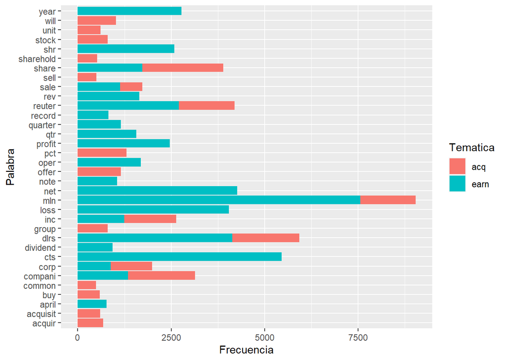

```r
# Cargamos la librería:
library(ggplot2)

# Creación del gráfico de barras apiladas, en posición horizontal:
ggplot(subset(fdata, Frecuencia>100))+ geom_col(aes(Palabra,Frecuencia,fill=Tematica))+coord_flip()
```

¿Qué implica la existencias de estas barras con un solo color?

> Hay barras que aparecen en un solo color y otras en dos, esto se debe a que hemos aplilado las barras. Las barras que corresponden a términos que aparecen en las dos temáticas, aparecerán en dos colores, teniendo una predominancia mayor en la barra el color que pertenezca a la temática en la que aparece más vecez el término. Si en algun caso la barra aparece solo en un color, significa que el término correspondiente solo aparece en una de las dos temáticas. El problema de apilar las barras de esta manera, es que es más difícil conocer el valor de los términos en los que coinciden los dos colores, ya que el punto de base no será 0, sino que será el final de la barra sobre la que se sitúa, por lo que perderemos esta perspectiva. Es decir, podremos ver el total de un término en las dos temáticas, pero es mucho más confuso ver cuantas veces aparece cada término por temática.

## 11.7 Ejercicio 4:

Se ha construido un modelo de clasificación con la función `knn()` y con la función `train()`. Describa las diferencias que hay en el tipo de entrenamiento del modelo realizado con cada función.

## 11.8 Respuesta 4:

> En el modelo knn el objetivo será predecir el tema de los documentos de pruebas. K-NN no genera un modelo fruto del aprendizaje con datos de entrenamiento, sino que el aprendizaje sucede en el mismo momento en el que se prueban los datos de test. A este tipo de algoritmos se les llama lazy learning methods.

> En la funcion knn() del paquete class, para cada columna del juego de datos de pruebas, se encuentra el k más cercano (en distancia Euclidiana) al juego de entrenamiento y la clasificación se decide por voto mayoritario, rompiendo los empates de manera aleatoria. Si hay empates para el k vector más cercano, todos los candidatos se incluyen en el voto. A parte de los argumentos train y test, incluye “cl” (factor de clasificaciones correctas del juego de entrenamiento), “k” (número de vecinos considerados), “l” (voto mínimo para una decisión definitiva), “prob” (si es True la proporción de votos para la clase ganadora aparace con el atributo prob), entre otros.

> En el caso de este ejercicio, se construye un juego de datos de entrenamiento con el 70% de los documentos y el de pruebas con el 30% restante y se realizan adaptaciones, como separar por un lado los temas y por otro la matriz de frecuencias. A la función knn() se le pasan los argumentos de entrenamientos para palabras y temas, y test o prueba para palabras. No se proporciona test para tema, ya que es esto lo que se quiere predecir.

> Una vez realizadas las matriz de confusión para el modelo knn, se obtienen unos resultados un poco diferentes a los del enunciado.

```r
#Real
#Predicción acq earn
#      acq  471   15
#      earn  19  825
```

> Se han revisado también los dos ratios para evaluar la capacidad predictiva del modelo y se ha obtenido:

```r
#ratio1= 96.12245
#ratio2= 98.21429
```

> Respecto a la funcion train(), ésta establece una malla de parámetros para afinar rutinas de clasificacion y regresión, adapta cada modelo, calcula y hace resampling según medidas de rendimiento. Para un modelo en concreto la malla de parámetros se crea y el modelo se entrena en datos que tienen pequeñas diferencias para cada combinación candidata de parámetros de afinación. A través de cada juego de datos, el rendimiento se calcula y la media y desviación estandard se resume para cada combinación. La combinación que tiene la estadística de resampling óptima se elige como modelo final y el juego de datos completo se usa para ajustar un modelo final.

> Pueden usar argumentos como “tunelength” para controlar cuantos valores de los parametros son evaluados, “tunegrid” cuando se desean unos valores concretos, “method” controla el tipo de resampling, entre otros.

> En el caso de este ejercicio, se ha creado una base de datos para las palabras y otro para los temas. Después se ha creado la malla con los valores k de 1 a 3, y se ha aplicado la funcion train() con los parámetros de entrenamiento, el metodo knn, y como tunegrid la malla creada. Una vez ejecutada la función train se han obtenido los siguientes resultados:

```r
#  k  Accuracy   Kappa
#  1  0.9688884  0.9324270
#  2  0.9665467  0.9274647
#  3  0.9665770  0.9276613
```

> Para seleccionar el modelo óptimo se ha usado el parámetro precisión, usando el valor más alto (que en este caso es k=1)

> En este caso, para el paquete “caret” la matriz de confusión da muchos más resultados que para el paquete “class”, ya que además de la precisión, la sensibilidad y la especificidad, esta matriz de confusión proporciona estadísticos que nos ayudan a valorar la capacidad informativa del modelo. Los resultados que nos da son:

```r
#          Reference
#Prediction acq earn
#      acq  471   14
#      earn  19  826

#              Accuracy : 0.9752
#                 95% CI : (0.9653, 0.9829)
#    No Information Rate : 0.6316
#    P-Value [Acc > NIR] : <2e-16

#                  Kappa : 0.9466

# Mcnemar's Test P-Value : 0.4862

#           Sensitivity : 0.9612
#            Specificity : 0.9833
#        Pos Pred Value : 0.9711
#        Neg Pred Value : 0.9775
#            Prevalence : 0.3684
#        Detection Rate : 0.3541
#  Detection Prevalence : 0.3647
#     Balanced Accuracy : 0.9723

#       'Positive' Class : acq
```

> Esta función en “caret” ha realizado una predicción solo un poco mejor que la de knn() con “class”, ya que solo ha fallado en 33 documentos, respecto a los 34 de knn(). La precisión es por tanto solo levemente más alta.

> Sin embargo el paquete Caret nos proporciona más información en su matriz de confusión, incluyendo kappa (que cuanto más cercana a 1 sea, nos indicará un mayor poder informativo del modelo) o el p-valor (que también mide el valor informativo del modelo, pero en este caso tiene que ser lo más bajo posible).

> Las estadísticas sensitivity, specificity, positive predictive value and negative predictive value se calculan utilizando el argumento “positive” que corresponde a un resultado positivo, en el que si hay dos niveles de factores, el primero será usado como resultado positivo.

> En general parece más óptimo utilizar el paquete caret y función train() en este caso, ya que la precisión es un poco mayor y nos proporciona una matriz de confusión más detallada e informativa.

## 11.9 Ejercicio 5:

En el apartado “Validación del Modelo de clasificación” se utiliza la función “knn” para clasificar los documentos según temática. Esta función por defecto supone que el número de vecinos a evaluar es igual a 1. ¿Qué dificultad añadida podría tener seleccionar un número de vecinos igual a 2?.

## 11.10 Respuesta 5:

> Knn es muy sensible a la escala de datos al depender de computos de distancia. Para escalas más altas, las disrancias calculadas pueden ser muy altas y producir malos resultados.

> El algoritmo selecciona las k instancias de entrenamiento más cercanas y se asigna la instancia a la clase más frecuente entre las k instancias seleccionadas como más cercanas. El num k indicaría el número de vecinos cercanos.

> El valor k suele fijarse tras un proceso de prueba con varias instancias dado que podemos obtener resultados muy distintos según el valor de k.

> En el caso de la matriz de confusión de “caret”, hemos obtenido una menor precisión y valor kappa para k=2:

```r
#  k  Accuracy   Kappa
#  1  0.9688884  0.9324270
#  2  0.9665467  0.9274647
```

> Añadir un k mayor supone también incrementar la lentitud del proceso de computación, ya que cada instancia de prueba es comparada con todo el juego de datos de entrenamiento y será la bondad de los resultados lo que determine el ajuste de k.

> Por otro lado, valores bajos de k pueden hacer el modelo más sensible al ruido y llevar a decisión más inestables, seria un modelo con más varianza, más flexible.

> Igualmente Usar un valor par en k no es recomendado porque hay riesgo de empate en la decisión de la clase, por lo que se suelen usar valores impares.

## 11.11 Ejercicio 6:

Del fichero inicial seleccionar dos temáticas distintas a las del enunciado y entrenar un k-NN utilizando la función `train()` que permita clasificar nuevos artículos en una de ambas temáticas. En la función `train()` defina una malla de valores para K impares entre 1 y 15, comente cuál es el valor óptimo y describa detalladamente como se realizaría una predicción de un nuevo dato.

## 11.12 Respuesta 6:

```r
## Cargamos los paquetes necesarios para ejecutar las funciones que se describen a continuación:
# Para la función Corpus()
library(tm)
# Para la función rbind.fill
library(plyr)
# Para la función knn()
library(class)

options(stringsAsFactors = FALSE)

# Leemos los datos
data <- read.table('E:/Análisis de datos/Fundamentos Data Science/PEC1/data_reuter.txt', header=FALSE, sep='\t')

#Cuantos documentos hay en total
nrow(data)
```

```
## [1] 5485
```

```r
# Cuantos hay para cada tipo de temática
table(data$V1)
```

```
##
##      acq    crude     earn    grain interest money-fx     ship    trade
##     1596      253     2840       41      190      206      108      251
```

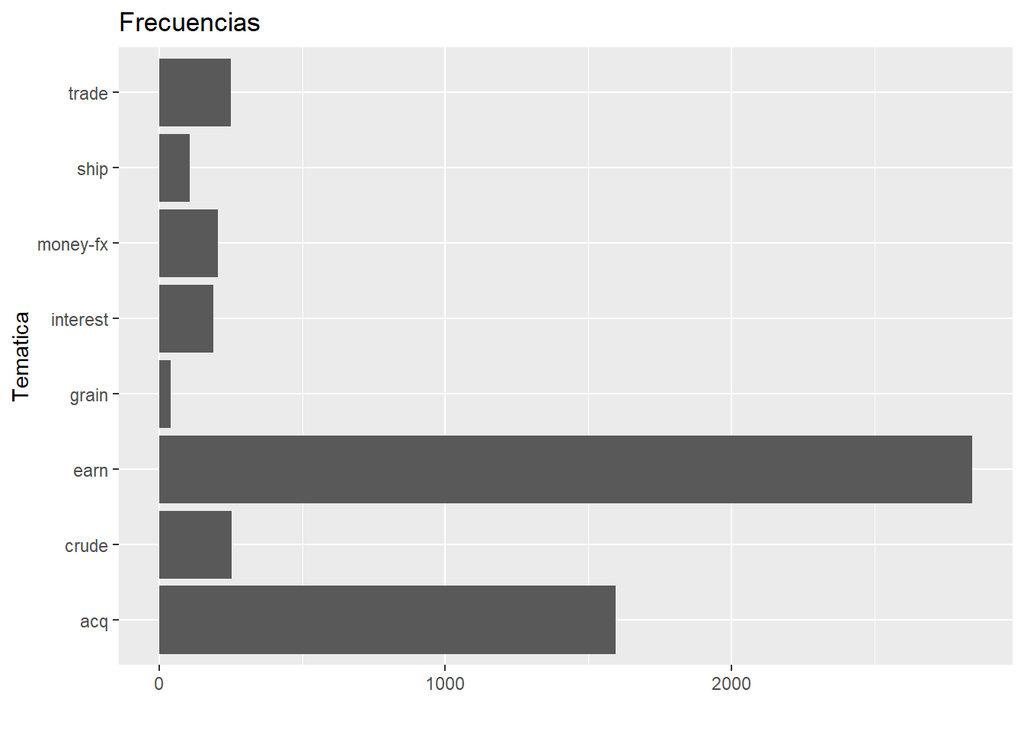

```r
library(ggplot2)
qplot(data$V1,xlab="Tematica", main = "Frecuencias")+ coord_flip()
```

```r
# Las temáticas que vamos a seleccionar son: "grain" y "trade"
data2<-data[which(data$V1 %in% c("grain","trade")),]
# Cuantos docs hay para las temáticas
nrow(data2)
```

```
## [1] 292
```

```r
# Ahora creamos el corpus de temática "grain"
## Seleccionamos la temática
data_grain<-data2[(data2$V1=="grain"),]
## Construimos el corpus
source <- VectorSource(data_grain$V2)
corpus1 <- Corpus(source)
## Acondicionamos el corpus
corpus1 <- tm_map(corpus1, content_transformer(tolower))
corpus1 <- tm_map(corpus1, removeNumbers)
corpus1 <- tm_map(corpus1, removePunctuation)
corpus1 <- tm_map(corpus1, stripWhitespace)
v_stopwords <- c(stopwords("english"),c("dont","didnt","arent","cant","one","also","said"))
corpus1 <- tm_map(corpus1, removeWords, v_stopwords)
corpus1 <- tm_map(corpus1, removePunctuation)
corpus1 <- tm_map(corpus1, stemDocument, language="english")

# Creación del corpus de la temática "trade"
## Seleccionamos la temática
data_trade<-data2[(data2$V1=="trade"),]
## Construimos el corpus
source <- VectorSource(data_trade$V2)
corpus2 <- Corpus(source)
## Acondicionamos el corpus
corpus2 <- tm_map(corpus2, content_transformer(tolower))
corpus2 <- tm_map(corpus2, removeNumbers)
corpus2 <- tm_map(corpus2, removePunctuation)
corpus2 <- tm_map(corpus2, stripWhitespace)
v_stopwords <- c(stopwords("english"),c("dont","didnt","arent","cant","one","also","said"))
corpus2 <- tm_map(corpus2, removeWords, v_stopwords)
corpus2 <- tm_map(corpus2, removePunctuation)
corpus2 <- tm_map(corpus2, stemDocument, language="english")

# Construimos la matriz de términos de la temática "grain"
mat_grain <- TermDocumentMatrix(corpus1)
inspect(mat_grain)
```

```
## <<TermDocumentMatrix (terms: 1342, documents: 41)>>
## Non-/sparse entries: 2937/52085
## Sparsity           : 95%
## Maximal term length: 14
## Weighting          : term frequency (tf)
## Sample             :
##             Docs
## Terms        11 17  2 27 29  3 31 34 38 39
##   agricultur  2  5  3  1  0  1  0  7  3  2
##   certif      0  0 13  0  0  0  0  0 13 21
##   crop        0  1  0  0  0 15  2  0  1  0
##   grain       6 18  2  8  5  9 14  1  2  7
##   mln         0 11  0  5  0  2  2  0  6  0
##   offici      2  9  2  0  0  1  9  1  1  0
##   reuter      2  2  2  2  2  1  1  1  1  1
##   soviet      0  0  0  0  0 13  0  0  0  0
##   will        3  5  3  2  2  5  3  1  2  0
##   year        5  4  0 12  0  3  6  2  2  2
```

```r
# Controlamos la dispersión (Sparsity): Número de celdas igual a cero respecto al total.
mat_grain<- removeSparseTerms(mat_grain,  0.80)
inspect(mat_grain)
```

```
## <<TermDocumentMatrix (terms: 30, documents: 41)>>
## Non-/sparse entries: 418/812
## Sparsity           : 66%
## Maximal term length: 10
## Weighting          : term frequency (tf)
## Sample             :
##             Docs
## Terms        11 17 19 27  3 31 34 38 39 7
##   agricultur  2  5  2  1  1  0  7  3  2 0
##   crop        0  1  2  0 15  2  0  1  0 0
##   grain       6 18  6  8  9 14  1  2  7 5
##   mln         0 11  5  5  2  2  0  6  0 0
##   offici      2  9  0  0  1  9  1  1  0 3
##   pct         0  1  0  3  3  1  2  0  4 0
##   reuter      2  2  1  2  1  1  1  1  1 2
##   soviet      0  0  2  0 13  0  0  0  0 5
##   will        3  5  1  2  5  3  1  2  0 1
##   year        5  4  4 12  3  6  2  2  2 3
```

```r
mat_grain<-list(name="grain",mat=mat_grain)
mat_grain
```

```
## $name
## [1] "grain"
##
## $mat
## <<TermDocumentMatrix (terms: 30, documents: 41)>>
## Non-/sparse entries: 418/812
## Sparsity           : 66%
## Maximal term length: 10
## Weighting          : term frequency (tf)
```

```r
str(mat_grain)
```

```
## List of 2
##  $ name: chr "grain"
##  $ mat :List of 6
##   ..$ i       : int [1:418] 1 2 3 4 5 6 7 8 9 10 ...
##   ..$ j       : int [1:418] 1 1 1 1 1 1 1 1 2 2 ...
##   ..$ v       : num [1:418] 1 1 3 4 1 1 1 2 3 1 ...
##   ..$ nrow    : int 30
##   ..$ ncol    : int 41
##   ..$ dimnames:List of 2
##   .. ..$ Terms: chr [1:30] "end" "fall" "grain" "pct" ...
##   .. ..$ Docs : chr [1:41] "1" "2" "3" "4" ...
##   ..- attr(*, "class")= chr [1:2] "TermDocumentMatrix" "simple_triplet_matrix"
##   ..- attr(*, "weighting")= chr [1:2] "term frequency" "tf"
```

```r
# Construimos la matriz de documentos de la temática "trade"
mat_trade <- TermDocumentMatrix(corpus2)
inspect(mat_trade)
```

```
## <<TermDocumentMatrix (terms: 3143, documents: 251)>>
## Non-/sparse entries: 21618/767275
## Sparsity           : 97%
## Maximal term length: 15
## Weighting          : term frequency (tf)
## Sample             :
##          Docs
## Terms     108 185 203 236 239 31 43 81 86  9
##   billion  11   3   1   2   1  6  0  1  1  2
##   countri   6   1   0  14   8  1  1  4  4  4
##   export   10   3   0   2   0  2  1  0  0 10
##   import    2   1  12   2   0  2  0  7  6  5
##   japan     5  13   8   4   3  1 10  1  1  0
##   japanes   0  13   4   0   0  0  5  0  0  0
##   reuter    1   2   1   1   2  1  1  1  1  1
##   trade    18  11   6   6   4  8  2 28 26 14
##   will      9   0  12   9   3  6  0  6  5  4
##   year      8   3   4   2   1  4  0  5  5  4
```